# Baby effort - modelling assumptions

## Force model

Assuming a fixed amount of force per attempt, estimate the number of attempts to success

threshold_probability_of_success = (0.8 by default) assume this probability of success is sufficient, we do not want to try too hard

force_required(prob_of_success_per_attempt) computes the number of unit attempts to achieve success using geometric distribution, based on probability of success learned from observations (e.g. adult demonstration)

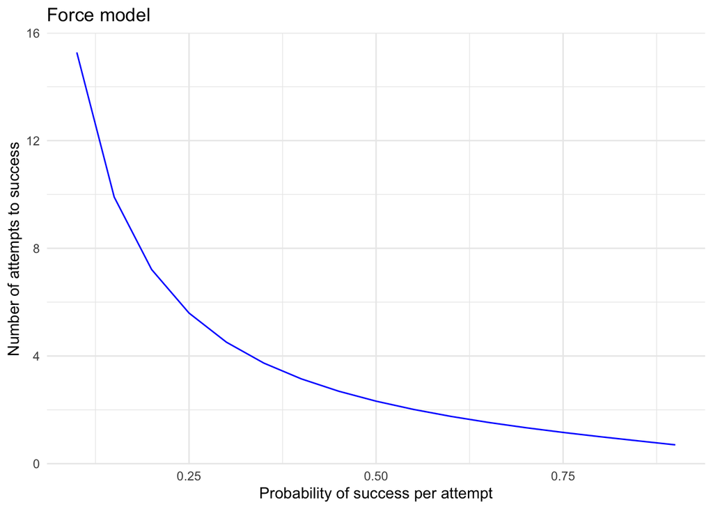

## Motivation model

Motivation scales the required force by a sigmoid function, such that the generated force does not exceed maximal motivation

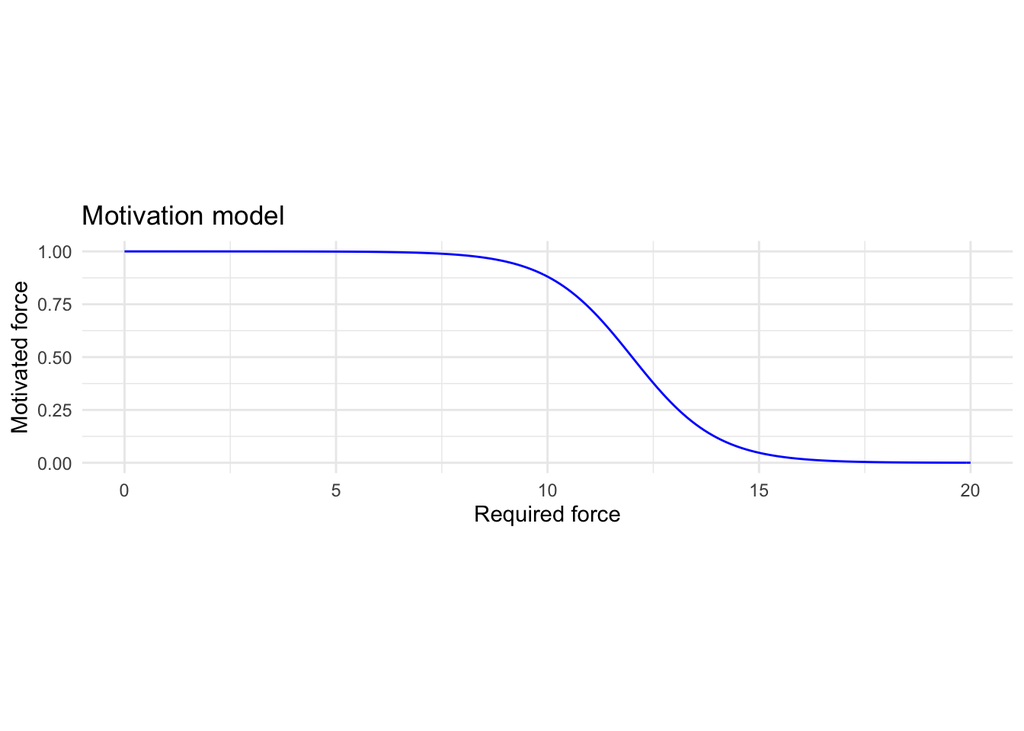

## Affect model

Affect is proportional to information theoretic surprise, given expected probabilit of success, and the observed outcome

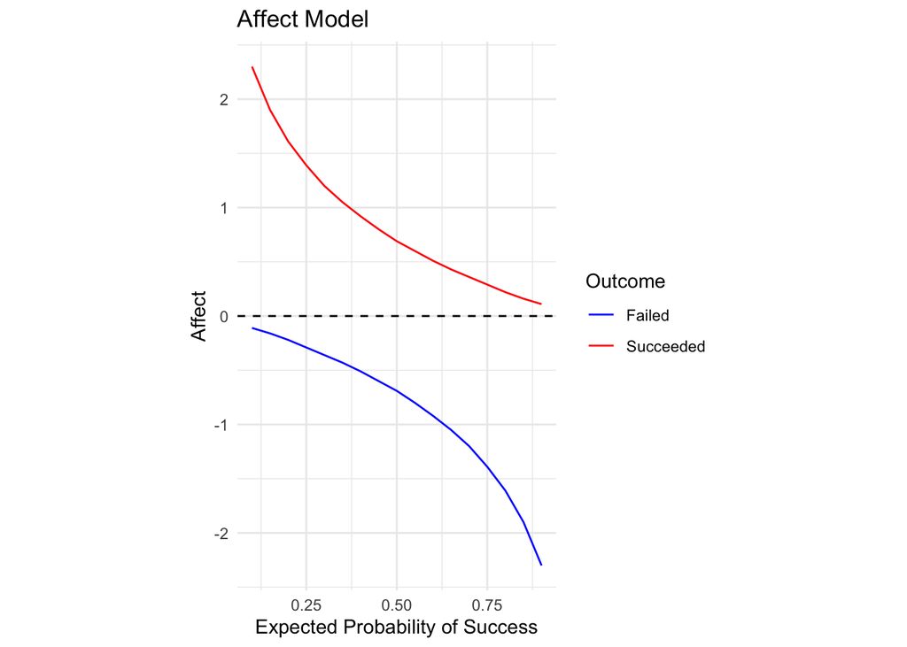

## Deciding if to request help

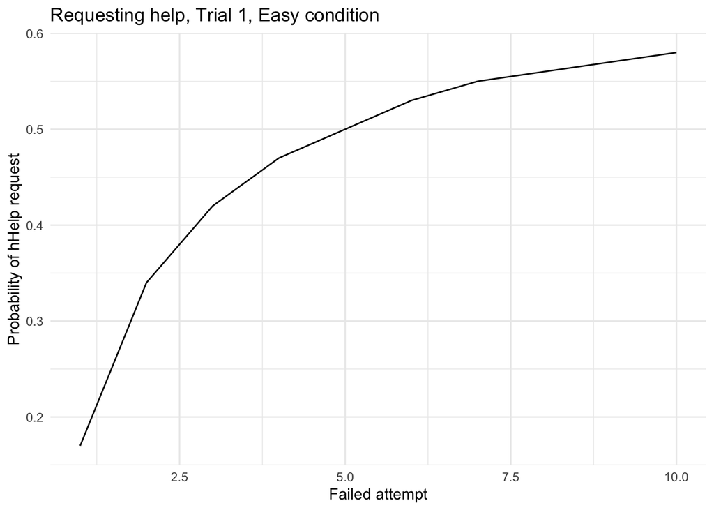

```r
adult <- list(a=2, b=1)

df = data.frame(attempt = 1, help = request_help(adult, list(a=1, b=1), k_helpseeking_willingness)   )
for (attempt in 2:10) {
  df = rbind(df,
    data.frame(attempt, help = request_help(adult, list(a=1, b=attempt), k_helpseeking_willingness)   )
  )
}

ggplot(df, aes(x = attempt, y = help)) + geom_line() + ggtitle("Requesting help, Trial 1, Easy condition") + xlab("Failed attempt") +
  ylab("Probability of hHelp request") + theme_minimal()
```

## A prior over task difficulty, and own success

Assume uninformative prior, which will be updated from observations

1. A prior over task difficulty, defined as the adult’s probability of success in this task per attempt. Assume adult applies a constant amount of force per attempt. This distribution learns about the feasibility of tasks in the experiment.
2. A prior distribution over own probability of success, given difficulty. This distribution learns own skill

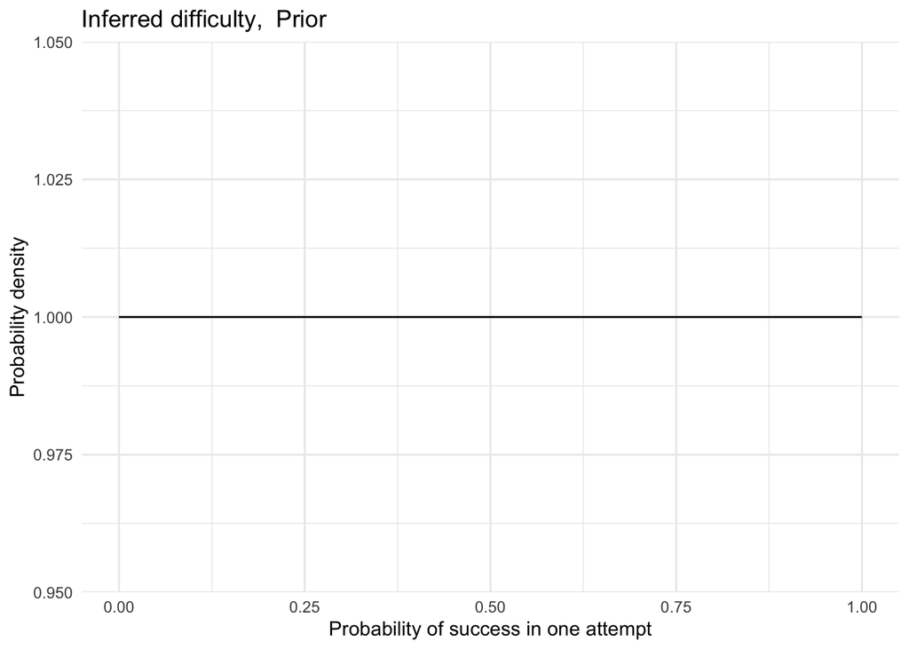

```r
# assume uninformative priors, to be fitted to individuals
plot_difficulty(difficulty, baby_success, "Prior")
```

## Observing Adult’s attempt, assume it is a success

Baby observes an adult attempting the task, and updates the distribution over task difficulty

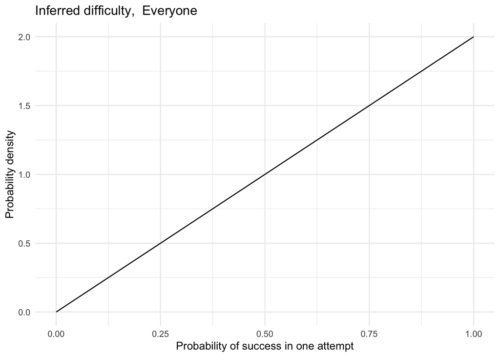

```r
adult_outcome = TRUE
r = observe_adult(adult_outcome, adult_success, baby_success)
adult_success = r$a
baby_success = r$b
plot_difficulty(difficulty, adult_success, "Everyone")
```

## Baby estimates force needed for the task

1. compute expected force needed for success, modeled as a cumulative number of attempts for a good chance of success, and adjust this force by motivation – how much force baby is willing to spend

## Baby generates attempt and observes outcome

1. compute expected affect from given the resulting force, assuming adult skill model
2. Update posterior belief over own skill
3. Decide whether to request help

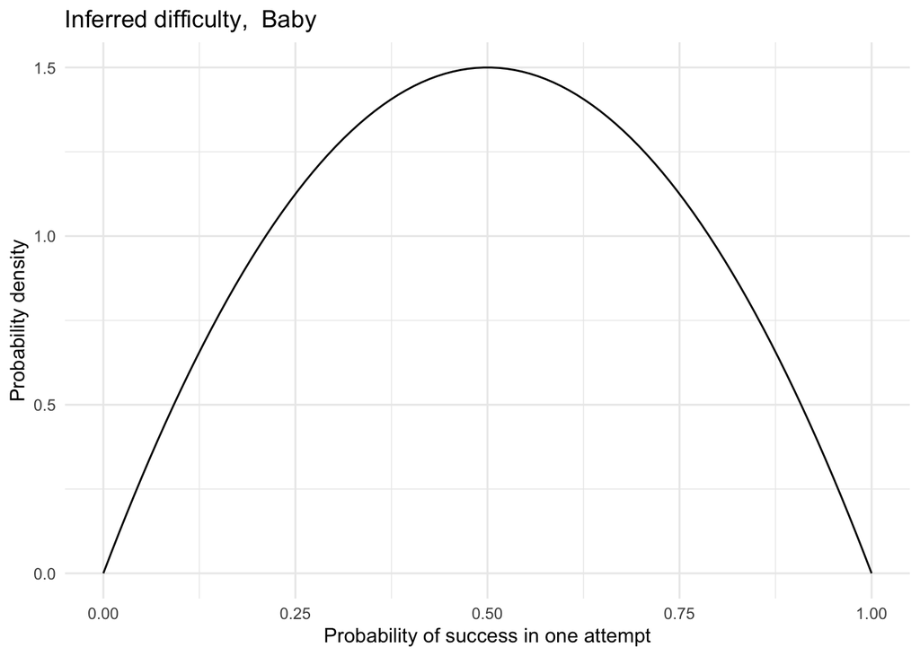

```r
required_attempts = force_required(expectation(baby_success))
force <- motivation_sigmoid(required_attempts, motivation_threshold)*required_attempts

expected_adult_outcome = prob_of_success(force, adult_success)

baby_outcome = FALSE  # observe outcome
baby_success = update_skill(baby_outcome, baby_success) # update baby's belief about own ability to solve this task
plot_difficulty(difficulty, baby_success, "Baby")
```

```r
a = affect(expected_adult_outcome, baby_outcome)
help = request_help(adult_success, baby_success, k_helpseeking_willingness)

print(paste("force:", force, "affect: ", a, "help request probability:", help))
```

```
## [1] "force: 1.46493457009917 affect:  -1.61 help request probability: 0.17"
```